# **R** 菜鸟入门

## 有用的信息：

| - | - |
| --- | --- |
| 安装和运行 | `cran, rstudio` |
| 数学基本运算符 | `+ - * / ^ %/% %%` |
| 常用函数 | `round() trunc() sqrt() abs() exp() log() log10() sin() asin()` |
| 赋值 | `<- = ->` |
| 作图 | `plot()` |
| 常用统计函数 | `sum() mean() max() min() range() median() sd()var()` |
| 其他 | R 菜鸟们，请早高峰时注意健康 |

## 第02篇 数据

在第 01 篇里，我们学会了用 **R** 进行一般的数学运算和统计计算，并且做出了两张图：拜罗伊特降水的季节变化图，北京的 PM2.5 日变化图。很好，只是，这些数据总不能一个一个敲到代码里吧。要是处理保存在其他文件里的大量数据呢？本篇就解决这个问题。

*开胃小菜： 在 Rstudio 左下窗口输入代码 demo(graphics)，然后按回车，再回车，再回车，再回车……*

点击[这里](http://dapengde.com/wp-content/uploads/2013/03/dapengde_DummyR_PM25.csv)下载一个数据文件，保存到一个文件夹里，比如 *c:\R\data* 文件夹（为避免不必要的麻烦，文件夹名称中都不要带空格和中文字符），我们看看如何对其中的数据进行操作。

首先，我们要告诉 **R** 数据在哪里。不习惯命令行的用户，可以这样获取这个文件的路径：

```
mydata1 <- file.choose() # 在弹出的窗口中选择文件，其路径存储到mydata里。
mydata1
```

这个文件的文件名叫做 *dapengde_DummyR_PM25.csv* 。鼠标选择文件比较麻烦，为了下次再使用这个代码的时候不必再点一次，一般都是直接输入文件路径：

```r
mydata2 <- "c:\\R\\data\\dapengde_DummyR_PM25.csv"  # 路径要用引号(单双都行)，表示这是一个字符串。
mydata2
```

```
## [1] "c:\\R\\data\\dapengde_DummyR_PM25.csv"
```

注意，文件路径中的斜线`\`本来是一个，但是在 **R** 代码中必须改成两个（ **切记切记！** ），或改成一个反斜线`/`，其中自有道理，暂时不必深究。

我们先在文件浏览器中双击打开这个文件看看，这是个 csv 文件，用记事本或 Excel 就可以打开，或者在 Rstudio 代码窗口输入

```
file.show(mydata2) # 查看文件
```

就会用默认程序打开。

这是2003 年 8 月在北京城区的三个高度（8 米，100 米，325 米）测得的 PM2.5 的质量浓度日变化（数据来源：Chan et al., 2005. Atmospheric Environment 39, no. 28 : 5113-5124），共 4 列 25 行。

现在让 **R** 读取文件。如果你喜欢拷贝粘贴的方式，那么可以在 Excel 选中数据区，拷贝，然后在 **R** 中这样读取其中的数据：

```
pm1 <- read.table(file = "clipboard", header = TRUE) # 读取剪切板里的数据，保存到 pm1 这个数据框变量里。header 表示数据的第一行为列名称。
```

Rstudio 右上窗就出现了 `pm1` 的信息，可以单击看内容，也可以用输入代码查看：

```
pm1
```

'read.table' 用来读取数据表格。看起来也太复杂了吧？怎么记得住？对，一般人都记不住，忘了就随手查查帮助，输入并运行：

```r
?read.table
```

Rstudio此时会在右下窗显示帮助信息，有详细的解释和实例。好好读读吧，以后你会发现， **问号+函数名** 是会经常用的命令。

**R** 菜鸟入门三大法宝：

- 第一法宝： **问号** ！问号+函数名，简直就是身边的诸葛亮，随时方便地查看帮助文档。
- 第二法宝： **google** 和 **wiki** ！大事不决问维基 ，小事不决问谷歌。
- 第三法宝： **论坛** ！内事不决问张昭（中文论坛，如[这里](http://cos.name/cn/)），外事不决问周瑜（英文论坛，如[这里](http://r.789695.n4.nabble.com/)）。

用拷贝粘贴的方式读取数据，优点是灵活，适合临时用一下。更多情况下，是直接按指定的路径去读文件：

```r
pm2 <- read.table(file = mydata2, header = TRUE, sep = ",")  # 读取逗号分隔的数据。sep 表示数据列的分隔符。
pm <- read.csv(file = mydata2)  # 与上一个命令等同，专门用来读逗号分隔的文件。
```

你要问 'read.csv'是怎么回事？请试试你的第一法宝。

数据画个图看起来更直观：

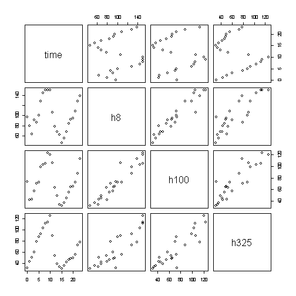

```r
plot(pm)
```

任意两列的散点图就这么容易地做出来了。如果你有十列八列的，就会发现这是多么省事啊！懒人的福音啊！dapeng 一般在读入数据文件后的第一件事就是`plot`一下，对数据有个整体的感觉。第二件事一般是看看这个文件的总结报告

```r
summary(pm)
```

```
##       time             h8             h100            h325
##  Min.   : 0.00   Min.   : 46.0   Min.   : 32.0   Min.   : 30.0
##  1st Qu.: 5.75   1st Qu.: 75.5   1st Qu.: 48.0   1st Qu.: 42.8
##  Median :11.50   Median : 93.5   Median : 67.5   Median : 54.5
##  Mean   :11.50   Mean   : 98.7   Mean   : 72.1   Mean   : 65.5
##  3rd Qu.:17.25   3rd Qu.:128.0   3rd Qu.:100.0   3rd Qu.: 88.5
##  Max.   :23.00   Max.   :150.0   Max.   :123.0   Max.   :126.0
```

这下可省事儿了，上一节我们用的最大值、最小值、中位数、平均值函数，用`summary`这一条命令就全部搞定，顺便还附送了四分位数（`1st Qu.， 3rd Qu.`）。啥是四分位数？试试你的第二法宝。

怎么选取 `pm` 中的指定数值呢，比如说，9 点钟 8 米高处的PM2.5浓度？还记得上一节我们是如何选取 4 月的降水量吗？对，`x[4]`。类似地：

```r
pm[9, 2]  # 第 9 行, 第 2 列。
```

```
## [1] 150
```

```r
pm[c(0, 2, 4, 6, 8, 10, 12, 14, 16, 18, 20, 22), 2]
```

```
##  [1]  80  91 100 144 150 106  68  46  68  92 108
```

这个 0 到 22 敲起来太麻烦了吧，懒人的办法是用`seq()`函数生成个数列：

```r
pm[seq(0, 22, 2), 2]
```

```
##  [1]  80  91 100 144 150 106  68  46  68  92 108
```

`seq(0, 22, 2)` 表示以 0 为起点，22 为终点，间隔（即步长）为 2 生成一个数列。比如步长是 1 的话，就用`seq(2, 22, 1)`。当然，更懒的做法是：

```r
pm[2:22, 2]
```

```
##  [1]  80  64  91  87 100 128 144 150 150 150 106  78  68  62  46  55  68
## [18]  84  92  95 108
```

选取整行或整列：

```r
pm[, 2]  # 第 2 列全部。
```

```
##  [1]  97  80  64  91  87 100 128 144 150 150 150 106  78  68  62  46  55
## [18]  68  84  92  95 108 128 138
```

```r
pm[3, ]  # 第 3 行全部。
```

```
##   time h8 h100 h325
## 3    2 64   43   50
```

如果列数太多，总不能老去数第几列吧？别急，也可以这样选取：

```r
pm[, "h8"]
```

```
##  [1]  97  80  64  91  87 100 128 144 150 150 150 106  78  68  62  46  55
## [18]  68  84  92  95 108 128 138
```

或者用美元符号

```r
pm$h8
```

```
##  [1]  97  80  64  91  87 100 128 144 150 150 150 106  78  68  62  46  55
## [18]  68  84  92  95 108 128 138
```

`h8` 是要选取的列的名称。列名称都有哪些呢？用`names()`函数：

```r
names(pm)
```

```
## [1] "time" "h8"   "h100" "h325"
```

```
练习02.1：请做出 100 米高处的 PM2.5 浓度日变化的散点图。
练习02.2：请计算 100 米高处 PM2.5 浓度的平均值，最大值，最小值，中值。
```

从此以后，只要把你的数据文件保存成.csv文件，**R** 就可以容易地读取，进行后续处理了！

## 有用的信息：

| - | - |
| --- | --- |
| 数据文件存储路径 | 不要空格，不要中文，读取时用双斜线。 |
| 读取文件 | `read.table(), read.csv()` |
| 选取单元格 | `pm[3, 2]，pm[ , 2]，pm[3, ]，pm[,"h8"]，pm$h8` |

## 第03篇 画图

在上两篇中，我们都用到了 `plot` 命令来作图。如果说 Excel 作图的方法是先按照默认的格式画好之后再让你涂涂改改，那么 **R** 作图的流程更亲切：铺开一张白纸，打好格，画数据点，画坐标轴，加图例。就像用纸笔画图。不像 Excel 那样自作聪明。每一步都清清楚楚掌控在你手里。

*开胃小菜： 在 Rstudio 左下窗口输入代码 demo(persp)，然后按回车，再回车，再回车，再回车……*

这里，我们接着上一篇读取的数据 pm，来画一些更漂亮的图片。

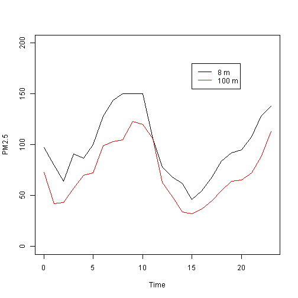

```
练习03.1：请用问号查询 plot、lines、legend 的帮助文件。
```

```r
pm <- read.csv(file = "c:\\R\\data\\dapengde_DummyR_PM25.csv")
plot(x = pm$time, y = pm$h8, xlab = "Time", ylab = "PM2.5", type = "l", ylim = c(0,
    200))  # 以小时为 x 轴，8 米处的 PM2.5 浓度为 y 轴作图。设定两个坐标的名称。数据点类型为 l 即线型。设定 y 轴范围。
lines(x = pm$time, y = pm$h100, col = "red")  # 添加 100 米处 PM2.5 浓度曲线。
legend(x = 15, y = 180, legend = c("8 m", "100 m"), col = c("black", "red"),
    lty = 1)  # 添加图例。
```

添加图例的位置有多种设置方法。上面的例子是用坐标位置确定的。还可以用内置模板来指定：

```
legend("topleft", legend = c("8 m", "100 m"), col = c("red", "black"), lty = 1) # 图例添加在左上角。
legend(locator(1), legend = c("8 m", "100 m"), col = c("red", "black"), lty = 1) # 用鼠标确定图例的位置。
```

做出的图片出现在 Rtudio 右下窗，可以点击 *Export*，选择保存的格式和路径就可以了。不过，更经常用的是命令行方式：

```
pdf(file = "c:\\R\\data\output.pdf") # 打开一张pdf的白纸。
plot(x = pm$time, y = pm$h8, xlab = "Time", ylab = "PM2.5 at 8 m", type = "l", ylim = c(0, 200)) # 在白纸上画图
dev.off() # 画完了，把纸张收起来
```

下面，我们让图片复杂一点：

```
pdf(file = "c:\\R\\data\output2.pdf", width = 8, height = 5) # 设定纸张大小。
plot(x = pm$time, y = pm$h8, xlab = "Time", ylab = "PM2.5 at 8 m", type = "l", ylim = c(0, 200), axes=FALSE) # 画图，但坐标轴先空着。
axis(2) # 在左边画出 y 轴。
axis(4) # 在右边画出 y 轴。
axis(1, at = 0 : 23, labels = 0 : 23) # 在下面画出x轴，并在指定位置（at）标出刻度（labels）。
points(x = pm$time, y = pm$h100, col = "red", type = "l") # 增加一条线。
points(x = pm$time, y = pm$h325, col = "blue", type = "l") # 再增加一条线。
abline(h = c(10, 15 , 25, 35), col = "grey", lty = 2) # 增加几条水平线(世界卫生组织推荐的健康标准值)。
legend("top", legend = c("8 m", "100 m", "325 m"), col = c("red", "black", "blue"), lty = 1) # 添加图例。
box() # 画出边框。
dev.off()
```

散点图以外的图，用其他的命令，例如：

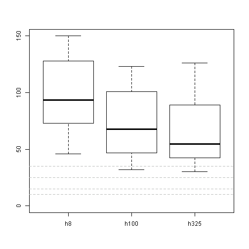

```
练习03.1：请给上面boxplot做的图添加图例，并保存为pdf。
```

```r
boxplot(pm[, c("h8", "h100", "h325")], ylim = c(0, 150))
abline(h = c(10, 15, 25, 35), col = "grey", lty = 2)
```

**R** 的作图功能超级强大，看看[这里](http://gallery.r-enthusiasts.com)有很多例子，包含了源代码。

## 有用的信息：

| - | - |
| --- | --- |
| 作图 | `plot(), boxplot()` |
| 图上添加数据点和线 | `points(), lines(), abline(), box(), axis()` |
| 添加图例 | `legend()` |
| 保存图片 | `pdf()` |

## 第04篇 模型

这一篇，我们试着进行线性拟合，示例所用的数据仍然是前两篇中的北京 PM2.5 质量浓度。

*开胃小菜： 在 Rstudio 左下窗口输入代码 example(nls)，然后按回车，再回车。*

经过了前几篇的练习，相信你已经熟悉了 # 号注释的方式。从今往后，我们尽量以这种方式来缩短文字篇幅。

```r
pm <- read.csv(file = "c:\\R\\data\\dapengde_DummyR_PM25.csv")
m <- lm(pm$h100 ~ pm$h8)  # 线性拟合
m  # 查看模型，显示斜率和截距。
```

```
##
## Call:
## lm(formula = pm$h100 ~ pm$h8)
##
## Coefficients:
## (Intercept)        pm$h8
##     -11.471        0.846
```

```r
summary(m)  # 模型的详细总结报告。
```

```
##
## Call:
## lm(formula = pm$h100 ~ pm$h8)
##
## Residuals:
##     Min      1Q  Median      3Q     Max
## -14.247  -7.113  -0.397   4.508  27.744
##
## Coefficients:
##             Estimate Std. Error t value Pr(>|t|)
## (Intercept)  -11.471      6.013   -1.91     0.07 .
## pm$h8          0.847      0.058   14.58  8.6e-13 ***
## ---
## Signif. codes:  0 '***' 0.001 '**' 0.01 '*' 0.05 '.' 0.1 ' ' 1
##
## Residual standard error: 8.94 on 22 degrees of freedom
## Multiple R-squared: 0.906,   Adjusted R-squared: 0.902
## F-statistic:  213 on 1 and 22 DF,  p-value: 8.64e-13
```

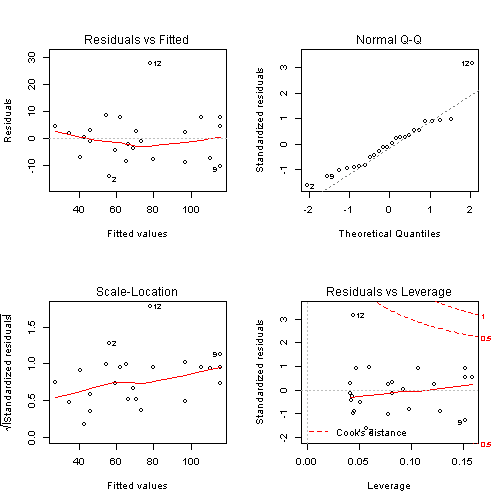

```r
# 下面对拟合结果作图。
par(mfrow = c(2, 2))  # 把一张作图纸上分成两行两列。par() 在作图时很有用，请查看帮助。
plot(m)
```

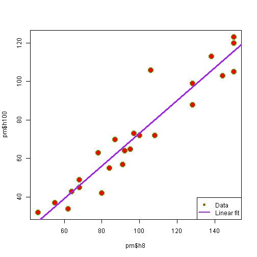

```r
# 作图完毕。 给散点图添加拟合直线。
par(mfrow = c(1, 1))
plot(pm$h8, pm$h100, cex = 2, pch = 21, bg = "red", col = "green")
abline(m, col = "purple", lwd = 3)  # 添加趋势线
legend("bottomright", pch = c(21, NA), lty = c(NA, 1), legend = c("Data", "Linear fit"),
    pt.bg = "red", col = c("green", "purple"), lwd = c(NA, 2))
```

## 有用的信息：

| - | - |
| --- | --- |
| 线性拟合 | `lm()` |
| 非线性拟合 | `nls()` |
| 作图设置 | `par()` |

## 第05篇 循环

前两天 dapeng 用 **R** 给师妹做了一张"全国各省 PM10 浓度地图"，以省会城市的 PM10 浓度值给各省涂上颜色，结果师妹说：这个用 ArcGIS 能又快又好地做出来。 dapeng 脑子里立刻涌现出多种说法要细数 **R** 的优势，第一条就是：若是有 20 年的数据，每年做一张图，**R** 菜鸟用简单一个循环就能编程搞定，ArcGIS 该怎么又快又好做出来？若不是资深用户的话，我等菜鸟恐怕得一张一张图点出来吧？这种操作费时费力并且毫无乐趣，就应该交给机器来解决，这是懒人的必备技能。本篇就来说说程序的基本结构之一：循环。

*开胃小菜* *男人至少要擅长一项运动,一种乐器,一种编程….和拿手的几个小炒. (语出[小鸟学AHK](http://hi.baidu.com/cttfssdtvxbgsyr/item/33a1304c9baa55e6bdf451a6))*

所谓循环，就是兜圈子，就是一件事情重复操作。先从一个简单例子开始。在第 03 篇中，我们对 8 米和 100 米两个高度处测量的 PM2.5 做了日变化图。若要对三个高度的每一个都做日变化图，不用循环，那么是这样的：

```
pm <- read.csv(file = "c:\\R\\data\\dapengde_DummyR_PM25.csv")
par(mfrow=c(1， 3))
plot(pm[, 1], pm[, 2], cex = 2, type = "l") # 第一张图
plot(pm[, 1], pm[, 3], cex = 2, type = "l") # 第二张图
plot(pm[, 1], pm[, 4], cex = 2, type = "l") # 第三张图
```

如果使用循环，是这样的：

```
par(mfrow=c(1,3))
for (i in c(2, 3, 4)) plot(pm[, 1], pm[, i], cex = 2, type = "l") # 让 i 的取值在2, 3, 4这三个数中转一圈，做第 i 张图。
```

这里出现的 `for()` 就是循环语句。看起来跟不用循环也差不多嘛。是的。但是有一次 dapeng 要给 20 个观测点 一个月的 PM2.5 每天做一张日变化图来，总共要做 600 张，要是不用循环，那恐怕连死的心都有了。话说 dapeng 当年第一次接触计算机程序的时候，就为循环语句兴奋得睡不着觉，那种久旱逢甘露感觉记忆犹新。懒人福音啊！

`i` 转的那个圈，可以是数字，也可以是别的，比如字符串：

```
for (i in c("Good", "Morning", "!")) print(i)
```

```
练习05.1 用`print()` 指令打印 1 到 100 之间的奇数。
```

**R** 中常用的循环语句，除了 `for()` 之外，还有`while()` 和 `until()`，相互之间可以换用。

下面我们用循环语句来做一个指数增长模型，再体会一下循环的意义。

指数增长模型，也叫马尔萨斯增长模型，一个函数的增长率与其函数值成比例。举个例子吧，我们用 `N1` 表示 2008 年世界总人口 66.8 亿，r 表示人口自然增长率，为简化起见假定 `r` 是个常数 0.011，那么在下一年的总人口就是 `N2 = N1 + r * N1`。我们想看看今后一百年的人口总数，可以这样做：

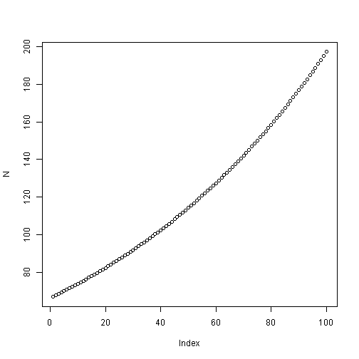

```r
# 方法 1：每年分别计算，分别存储人口数。
N1 <- 66.8
r <- 0.011
N2 <- N1 + r * N1
N3 <- N2 + r * N2  # 如此一直写到 N100。

# 方法 2：每年分别计算，用一个向量来存储各年人口总数。
N <- numeric(100)
N[1] <- 66.8
N[2] <- N[1] + r * N[1]
N[3] <- N[2] + r * N[2]  # 如此一直写到 N[100]。

# 方法 3： 用循环语句计算，用一个向量来存储各年人口数。
N <- numeric(100)
N[1] <- 66.8
for (t in 1:99) N[t + 1] <- N[t] + r * N[t]  # 不必一直写到N100。
plot(N)
```

循环的好处一览无余！

上面的例子里，每次重复的操作只有一条指令，所以直接写在 for () 后面就可以了。实际遇到的情况往往是重复一组指令，比如 每次给 N[t+1] 赋值时想显示一下当年人口和年份，那么可以用花括号把一组指令组合起来：

```
for(t in 1:99)
{
N[t+1] <- N[t] + r * N[t]
print(t + 2007)
print(N[t+1])
}
```

到目前为止，**R** 中所有的括号都闪亮登场了一遍，这里小结一下它们的角色：

- 圆括号 ()。用作命令和数学表达式，如 `mean(x), (1 + 2) * 3`。
- 方括号 []。用作下标，调用向量中的某个元素，如`x[3], pm[2,6]`。
- 花括号 {}。用作编程，把一组指令组合在一起，如`for () {}`。

```
练习05.2 生成一个矩阵 m （方法见 matrix 函数的帮助信息），使得 m[i,j] = x[i] * y[j]， 其中 x <- c(2, 3, 5)， y <- c(1, 2, 3, 4)。
```

## 有用的信息：

| - | - |
| --- | --- |
| 循环语句 | `for(), while(), until()` |
| 括号的用法 | `() [] {}` |

## 第06篇 分支

顺序、循环和分支是编程的三大结构。上一篇说了循环，这一篇说说分支。

啥是分支？分支就是你到了一个路口，向左向右向前看，要选择到底往哪个方向走。每时每刻我们都要做出选择：渴了，是喝咖啡还是茶？见了人，是上去打招呼还是悄悄躲开？这篇帖子，是关掉还是继续读下去？其实仔细想想，岂止是编程，那三大结构简直就是整个生活的基本结构：日出日落，月圆月缺，年尾年头，这是循环；上学还是就业，单身还是结婚，丁克还是生娃，这是分支；不管是循环还是分支，都嵌入在生老病死的时间轴上，这是顺序。所谓尽人事听天命，想来就是心平气和地接受顺序结构，小心翼翼地制订循环结构，在关键时刻控制好分支结构，就这样度过一生罢。

扯远了。简单来说，分支就是先判断再选择。

先判断。判断要用逻辑运算。我们先来做一套健脑操热热身：

```r
3 > 2  # 3比2大吗？是的。
```

```
## [1] TRUE
```

```r
1 > 2  # 1比2大吗？不是的。
```

```
## [1] FALSE
```

```r
!(1 > 2)  # 1不比2大吗？呃......
```

```
## [1] TRUE
```

```r
3 > 2 & 1 > 2  # 3比2大，并且1比2大吗？不是的。
```

```
## [1] FALSE
```

```r
3 > 2 | 1 > 2  # 3比2大，或者1比2大吗？是的。
```

```
## [1] TRUE
```

```r
3 > 2 & !(1 > 2)  # 3比2大，并且1不比2大吗？好像是吧......
```

```
## [1] TRUE
```

好了，热身完毕。包括上面出现的，常用的逻辑运算符有：`大于 >， 小于 <， 等于 ==， 小于或等于 <=， 大于或等于 >=， 与 &， 非 !， 或|`。

逻辑运算符用在向量上：

```r
x <- 1:3
x == 2
```

```
## [1] FALSE  TRUE FALSE
```

```r
x == 2 | x == 3
```

```
## [1] FALSE  TRUE  TRUE
```

```r
y <- c(4, 1, 2)
x > y
```

```
## [1] FALSE  TRUE  TRUE
```

```r
x > y & y > 1
```

```
## [1] FALSE FALSE  TRUE
```

```
练习06.1 设 x <- 6:1，y <- c(3, 5, 7)，判断 x 中的每个元素是否在y中出现。
```

上面这个练习可以用循环来完成。不过，由于 **R** 很照顾懒人，所以提供了更方便的方法：

```r
x %in% y
```

```
## [1]  TRUE  TRUE FALSE
```

结合逻辑判断和下标系统，就可以挑出 x 中哪些元素出现在 y 中，以及出现的位置：

```r
x[x %in% y]
```

```
## [1] 1 2
```

```r
which(x %in% y)
```

```
## [1] 1 2
```

```
练习06.2 从 1:100 中挑出既能被 2 整除，又能被 3 整除的数（提示：判断整除的余数是否为零）。
```

下面，我们玩玩真实的观测数据。练习01.4 曾经提出个问题：PM2.5 一天中的最大值出现在几点钟？当时需要肉眼判断，现在可以交给机器了。

```r
pm <- read.csv("c:\\R\\data\\dapengde_DummyR_PM25.csv")
pm$time[which(pm$h8 == max(pm$h8))]
```

```
## [1]  8  9 10
```

```
练习06.3 世界卫生组织制订的 PM2.5 指导标准中最宽松的标准是 24 小时均值 75 微克每立方米。请挑出北京一天内超出此标准的时段。
```

上面讲的是分支两部曲的第一步：判断。下面说说第二步：选择。

```r
x <- 12
if (x < 99) print("x is less than 99")  # 如果()，那么。
```

```
## [1] "x is less than 99"
```

```r
x <- 12
if (x < 99) {
    print("x is less than 99")
} else {
    print("x is larger than 99")
}  # 如果()，那么{}，否则{}。
```

```
## [1] "x is less than 99"
```

```r
x <- 12
ifelse(x < 99, "small", "large")  # 等同于上一个例子，不同的是这里 x 的向量长度可以大于1，比如试试 x <- 98:100。
```

```
## [1] "small"
```

有了分支语句，就可以在很多地方派上用场了。继续以北京 PM2.5 日变化数据作图，把一天中的最大值重点标出来，然后把达标值用绿色区分出来：

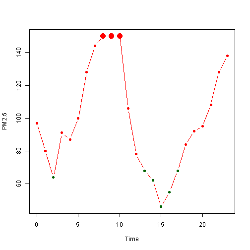

```r
plot(x = pm$time, y = pm$h8, xlab = "Time", ylab = "PM2.5", cex = ifelse(pm$h8 ==
    max(pm$h8), 2, 1), pch = 16, type = "b", col = ifelse(pm$h8 > 75, "red",
    "darkgreen"))
```

## 有用的信息：

| - | - |
| --- | --- |
| 逻辑运算 | > < == <= >= & ! |
| 分支命令 | `if () {}, if () {} else {}, ifelse()` |

## 第07篇 因子

前几篇举例子用的 PM2.5 数据来自十年前，这是因为 dapeng 手头碰巧有这么篇论文。今天偶尔发现，网上已经在公布最近国内城市的空气质量数据了，本篇就以北京和郑州两城市最近半个月的 PM2.5 数据举例子(数据来源 http://www.pm2d5.com/)。点击[这里](http://dapengde.com/wp-content/uploads/2013/03/dapengde_DummyR_PMBeijing.csv)下载北京数据，[这里](http://dapengde.com/wp-content/uploads/2013/03/dapengde_DummyR_PMZhengzhou.csv)下载郑州数据，请仍然保存在 *c:\R\data\* 文件夹下面。

```r
bj <- read.csv(file = "c:\\R\\data\\dapengde_DummyR_PMBeijing.csv")
zz <- read.csv(file = "c:\\R\\data\\dapengde_DummyR_PMZhengzhou.csv")
bj$city <- "Beijing"
zz$city <- "Zhengzhou"
data <- rbind(bj, zz)  # 按行合并数据。
summary(data)
```

```
##       date             pm          city
##  Min.   : 1.00   Min.   :  5   Length:37
##  1st Qu.: 5.00   1st Qu.: 51   Class :character
##  Median :10.00   Median : 75   Mode  :character
##  Mean   : 9.76   Mean   : 95
##  3rd Qu.:14.00   3rd Qu.:115
##  Max.   :19.00   Max.   :280
```

```r
str(data)
```

```
## 'data.frame':    37 obs. of  3 variables:
##  $ date: int  1 2 3 4 5 6 7 8 9 10 ...
##  $ pm  : int  5 27 75 22 130 228 220 205 63 35 ...
##  $ city: chr  "Beijing" "Beijing" "Beijing" "Beijing" ...
```

```r
data$city <- factor(data$city)
str(data)
```

```
## 'data.frame':    37 obs. of  3 variables:
##  $ date: int  1 2 3 4 5 6 7 8 9 10 ...
##  $ pm  : int  5 27 75 22 130 228 220 205 63 35 ...
##  $ city: Factor w/ 2 levels "Beijing","Zhengzhou": 1 1 1 1 1 1 1 1 1 1 ...
```

现在，data$city 是个因子了。因子的取值叫做“水平”(level)。看看因子有几个水平，水平分别是什么：

```r
nlevels(data$city)
```

```
## [1] 2
```

```r
levels(data$city)
```

```
## [1] "Beijing"   "Zhengzhou"
```

因子有什么用呢？当然就是用来对数据分类了。请看下面的例子：

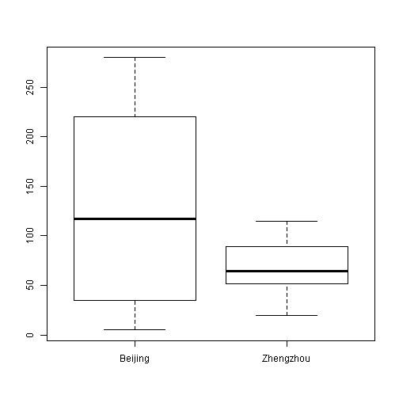

```
练习07.1 把示例数据中的日期列转换成因子，并按日期分类做出箱型图。
```

```r
plot(x = data$city, y = data$pm)  # 当x是因子时，plot自动画出箱型图。等同于boxplot(data$pm ~ data$city)
```

```r
# 分别计算两地最近18天的PM2.5平均值。
for (i in levels(data$city)) {
    print(i)
    print(mean(data$pm[data$city == i]))
}
```

```
## [1] "Beijing"
## [1] 125
## [1] "Zhengzhou"
## [1] 66.8
```

```r
tapply(data$pm, data$city, mean)  # 跟上一条循环指令的作用相同。懒人的福音又来了！
```

```
##   Beijing Zhengzhou
##     124.7      66.8
```

dapeng 是太喜欢 `tapply()`了。以前处理过这么个数据文件，有两列，第一列是日期，第二列是日均气温值，每天一行，总共一年，365 行，需要计算月平均气温。因为各月的天数是不同的，dapeng 只好在 Excel 里用鼠标拖，或者数单元格的位置，一共算了 12 次，还庆幸幸好只有 365 行。后来才知道 Excel 有“数据透视表”这个东西，但仍然觉得不灵活。现在有了 **R**，只要增加一列月份因子（方法以后专门介绍），一条 'tapply()' 就搞定，就算是有三万六千行，也不费吹灰之力了。

```
练习07.2 用tapply()和示例数据，分别计算北京和郑州两城市最近 PM2.5 日均值的最大值、最小值、中值。
```